# Untitled

```r
library(tidyverse)
#install.packages('binom')
library(binom)
library(gganimate)
```

The adequacy of an e-discovery production has traditionally been established by using random sampling to estimate recall, but that requires review of approximately 400/ρ documents, where ρ is the prevalence, which can be burdensome when prevalence is low.

We have a courpus of n documents.

```r
num_docs <- 1000
```

Prevalence is the actual number of responsive documents in the corpus. It is a number from 0 to 1. Also know as richness or yield.

```r
prevalence <- .1
```

Responsive documents are those that are relavent to a matter.

Recall is the percentage of found responsive items. It is tp / (tp + fn). Precision is the percentage of found items that are responsive. It is tp / (tp + fp).

The discard set or negatives are the items that have not been reviewed.

The proportion of the discard set that is responsive is known as the elusion or false omission rate. THis can be confiremd to be below a certain level reviewing a random set and having none of them be responsive.

recall (R), elusion (E) and prevalence (P) relationshiop

```
Elusion = Prevalence * (1 - Recall) / (1 - (Prevalence / Precision) * Recall)
```

[This was a good read](https://e-discoveryteam.com/tag/recall/)

Some process will return a collection of documents, this is the responsive docs.

This generates a random sample that is close to prevalence

```r
doc <- sample(c(0, 1), num_docs, replace = T, prob = c(1 - prevalence, prevalence))
```

But we actually want to force this

```r
doc <- c(rep(1, num_docs * prevalence), rep(0, num_docs * (1 - prevalence)))

# Just to make sure they are shuffled around.
doc <- sample(doc)

mean(doc) == prevalence
```

```
## [1] TRUE
```

Iterate over number pulled

```r
# Function to sample docs.
gen_set <- function(n) sample(doc, n)

df <- data.frame(size = numeric(), mean = numeric(), std = numeric()) %>% as_tibble()

for (i in 1:50) {
  res <- sapply(1:2000, function(x) mean(gen_set(i)))

  df <- bind_rows(df, data.frame(size = i, mean = mean(res),
                                 std = sd(res), mx = max(res), mn = min(res)))
}

df %>% mutate(upper = mean + std, lower = mean - std) %>%
  select(-std) %>% gather(type, val, -size) -> df2
```

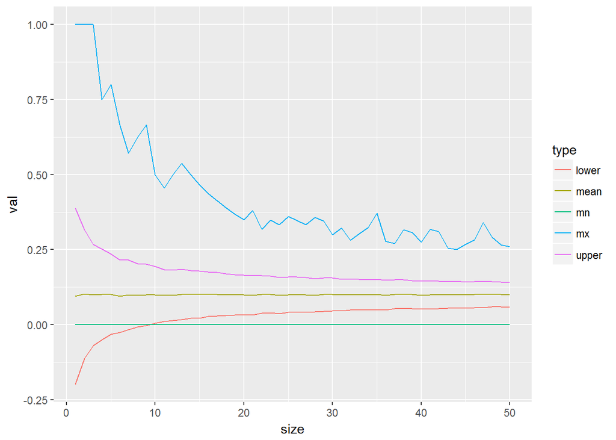

```r
ggplot(df2, aes(x = size, y = val, colour = type)) + geom_line()
```

We know the actual prevalence. Can we determine how valid this all is.

```r
bn <- data.frame(size = numeric(), mean = numeric(), upper = numeric(),
                 lower = numeric())

for (i in 1:200) {

  x <- gen_set(i)
  #res <- sapply(1:1, function(x) mean())
  y <- binom.confint(x = sum(x), n = i, tol = 1e-8) %>% filter(method == 'bayes')

  bn <- bind_rows(bn, data.frame(size = i, mean = y$mean, y$upper, y$lower))
}
```

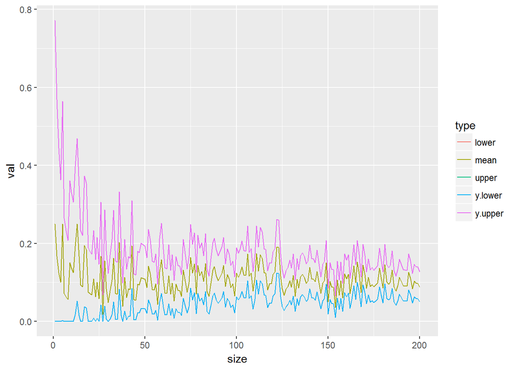

```r
bn %>% gather(type, val, -size) -> bn2




ggplot(bn2, aes(x = size, y = val, colour = type)) + geom_line()
```

YOu could do an approximate bayes here

```r
# The total number of documents
n_docs <- 1000

# THe total number of responsive docs
n_resp <- 100

# The number of docs we are going to review
n_rev <- 100

prev <- n_resp / n_docs


# Make the corpus
docs <- c(rep(1, n_docs * prev), rep(0, n_docs * (1 - prev)))


rev_docs <- sample(docs, n_rev)


prior_mu <- 1 / n_docs
prior_sd <- sqrt(((n_docs + 1) ^ 2 - 1) / 12)
prior_size_param <- -prior_mu^2 / (prior_mu - prior_sd^2)
n_socks <- rnbinom(1, mu = prior_mu, size = prior_size_param)



prop_pairs <- rbeta(1, shape1 = 15, shape2 = 2)
n_pairs <- round(floor(n_socks / 2) * prop_pairs)
n_odd <- n_socks - n_pairs * 2
```

```r
Recall <- function(pred, act) {
  # recall is tp / (tp + fn)
  tp <- sum(pred == 1)
  fn <- sum(act == 1) - sum(pred == 1)
  #fp <- sum(pred == 0)
  #tn <- sum(act == 0) - sum(pred == 0)
  #recall <- tp / (tp + fn)
  #precision <- tp / (tp + fp)
  #specificity <- tn / (tn + fp)
  #accuracy <- (tp + tn) / (tp + tn + fn + fp)
  tp / (tp + fn)
}
```

This is where the notion of 400 documents comes from.

Sample size https://www.qualtrics.com/blog/determining-sample-size/ 90% – Z Score = 1.645 95% – Z Score = 1.96 99% – Z Score = 2.576 (Z-score)2 * StdDev*(1-StdDev) / (margin of error)2 (2.576)^2* .5 * (1 - .5) / (.02)^2

```r
(1.96)^2 * .25 / (.05)^2
```

```
## [1] 384.16
```

We would say we need a sample of 385, always round, or go with 400 which is more common.

clopper pearson

```r
binom.test(300, 400, alternative = "two.sided", conf.level = 0.95)
```

```
##
##  Exact binomial test
##
## data:  300 and 400
## number of successes = 300, number of trials = 400, p-value <
## 2.2e-16
## alternative hypothesis: true probability of success is not equal to 0.5
## 95 percent confidence interval:
##  0.7045583 0.7916985
## sample estimates:
## probability of success
##                   0.75
```

https://blog.cluster-text.com/2014/09/08/erecall-no-free-lunch/

eRecall = 1 – FractionMissed / Prevalence FractionMissed / Prevalence = 1 - eRecall FractionMissed = (1 - eRecall) * Prevalence

```r
.25 * .01
```

```
## [1] 0.0025
```

```r
(0.001199478)
```

```
## [1] 0.001199478
```

```r
(0.004592768)
```

```
## [1] 0.004592768
```

eRecall = (TotalRelevant – RelevantDocsMissed) / TotalRelevant eRecall = 1 – RelevantDocsMissed / TotalRelevant (1 - eRecall) * TotalRelevant / TotalDocumentsCulled = FractionMissed

eRecall = 1 – FractionMissed / Prevalence

```r
1 - (0.001199478 / .01)
```

```
## [1] 0.8800522
```

```r
1 - (0.004592768 / .01)
```

```
## [1] 0.5407232
```

```r
# The population
num_docs <- 100000 # Thus there are 100k documents in the corpus.
prevalence <- .1

# Which means there are really this many true resp docs
num_docs * prevalence
```

```
## [1] 10000
```

```r
# Here we create the actual corpus.
doc <- tibble(doc_id = 1:num_docs,
              res = c(rep(1, num_docs * prevalence), rep(0, num_docs * (1 - prevalence))))
# And shuffle it around for good measure.
doc <- doc[sample(num_docs), ]



# By taking a sample we can see how decent of an estimate can we get for prevalence.
samp_size <- 400
prev_samp <- sapply(1:100, function(x) sum(sample_n(doc, samp_size)$res) / samp_size)
mean(prev_samp)
```

```
## [1] 0.1004
```

```r
sd(prev_samp)
```

```
## [1] 0.01372401
```

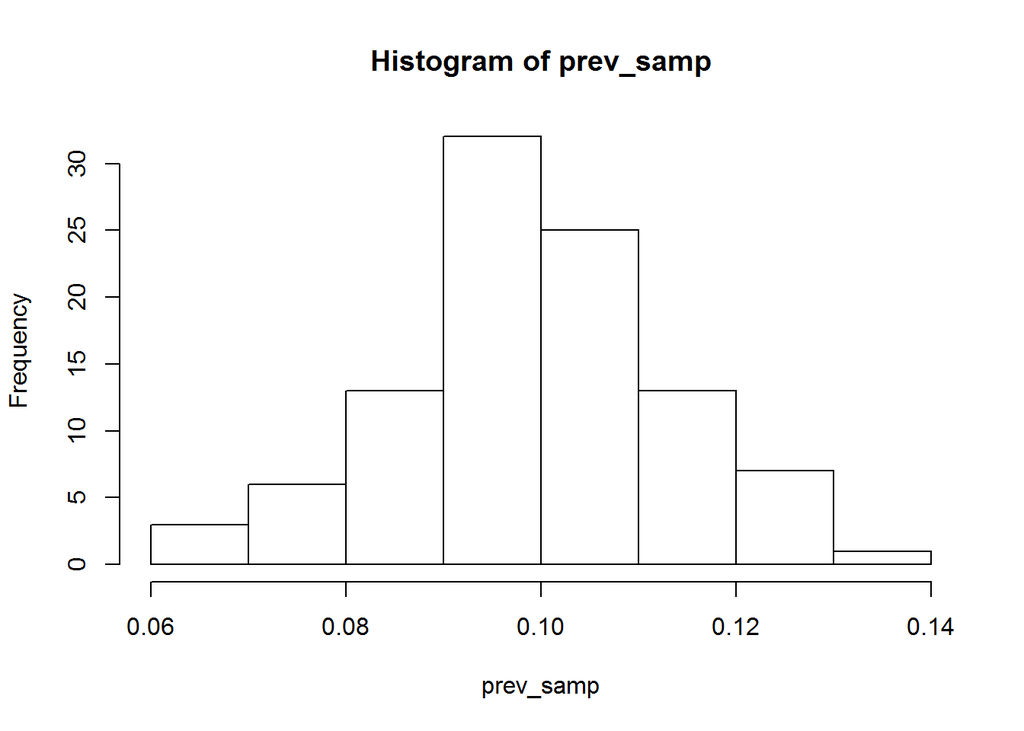

```r
hist(prev_samp)
```

```r
# This is an example of a TAR process, it returns a group to code as repsonsive.
# The value that goes into the first sample_frac will specify the Recall of this outcome,
# while the second one will specify 1 - Specificity
tar <- bind_rows(doc %>% filter(res == 1) %>% sample_frac(.75),
                 doc %>% filter(res == 0) %>% sample_frac(.05))

# Leaving this as the discard set.
discard <- doc %>% anti_join(tar, by = 'doc_id')

# Our recall is ...
Recall(tar$res, doc$res)
```

```
## [1] 0.75
```

```r
# Which it should be becuase we specified that in the above construction of the Tar set.


# There are a few methods that allow you to estimate various parameters of interest
# such as the recall, precision and prevalence. To start with, prev usually requires to
# find 400 random responsive docs. How hard is that.

# This would be the process of going through the docs to find 400 responsive.
prev_est <- which(cumsum(doc$res) == 400)[1]

y <- c()
for (i in 1:100) {
  doc <- doc[sample(nrow(doc)), ]
  y <- c(y, 400 / which(cumsum(doc$res) == 400)[1])
}
```

```r
#seq(round(min(min(y), min(prevs)), 2), round(max(max(y), max(prevs)), 2), length.out = 100)

entropy::KL.plugin(cut(prev_samp, seq(0, 1, .0005), labels = FALSE),
                   cut(y, seq(0, 1, .0005), labels = FALSE))
```

```
## [1] 0.01026286
```

```r
# direct method



calc_dir <- function(num = 400) {
  direct_method <- doc %>% filter(res == 1) %>% sample_n(num)
  length(intersect(direct_method$doc_id, tar$doc_id))
}

outcomes <- sapply(1:1000, function(x) calc_dir())

 # Need to accept above this value
400 * .7045583
```

```
## [1] 281.8233
```

```r
sum(sapply(1:1000, function(x) calc_dir() >= 282))
```

```
## [1] 985
```

```r
mean(sapply(1:1000, function(x) calc_dir()))
```

```
## [1] 300.021
```

```r
###
# We can see how often this works by looping through this

dat <- tibble(recall = numeric(), overlap = numeric(), c1 = numeric(), c2 = numeric())


for (i in 60:90) {
  tar <- bind_rows(doc %>% filter(res == 1) %>% sample_frac(i/100),
                   doc %>% filter(res == 0) %>% sample_frac(.05))
  for (j in 1:100) {
    overlap <- calc_dir()
    cv <- binom.test(overlap, 400, alternative = "two.sided", conf.level = 0.95)$conf.int
    dat <- bind_rows(dat, tibble(recall = i, overlap = overlap, c1 = cv[1], c2 = cv[2]))
  }
}


dat %>% mutate(recall = recall / 100) %>% group_by(recall) %>%
  summarise(prop = sum(recall > c1 & recall < c2) / n()) -> d
##



###############################################################################

# c(25, 8, 21, 9, 22, 11, 23, 14, 24, 16, 25, 17, 25, 20, 25)
# 50 22 38 26 40 29 41 32 43 35 45 39 47 43 49
# 100 50 70 56 74 63 78 69 82 75 85 82 90 88 94
# 200 111 129 122 138 134 148 145 156 157 165 169 173 181 183
# 400 240 241 260 261 280 281 300 301 320 321 340 341 360 361
```

```r
# randomly sample 400 from resp set
#samp <- sample(resp_set, 400)
#table(samp)

# You really do not need this.
#tar <- bind_rows(doc %>% filter(res == 1) %>% sample_frac(.75),
#                 doc %>% filter(res == 0) %>% sample_frac(.05))

tar <- (doc %>% filter(res == 1) %>% sample_frac(.75))$doc_id

multi <- function(num = 400) {

  hits <- cumsum((doc %>% filter(res == 1) %>% sample_n(num))$doc_id %in% tar)
       if ( hits[25]  <= 14)  0
  else if ( hits[25]  >= 24)  1
  else if ( hits[50]  <= 32)  0
  else if ( hits[50]  >= 43)  1
  else if ( hits[100] <= 69)  0
  else if ( hits[100] >= 82)  1
  else if ( hits[200] <= 145) 0
  else if ( hits[200] >= 156) 1
  else if ( hits[400] <= 300) 0
  else if ( hits[400] >= 301) 1
}


#y <- sapply(1:100, function(x) multi(sample(resp_set, 400)))

z <- sapply(1:5000, function(x) multi(400))
mean(z)
```

```
## [1] 0.4778
```

```r
sum(z)
```

```
## [1] 2389
```

```r
tar <- (doc %>% filter(res == 1) %>% sample_frac(.75))$doc_id
hits <- (doc %>% filter(res == 1) %>% sample_n(400))$doc_id %in% tar
```

```r
a <- 1
b <- 1
c <- 1
dist <- tibble(x = numeric(), y = numeric(), step = numeric())
for (j in 1:length(hits)) {
  i <- hits[j]
  if (i) a <- a + 1 else b <- b + 1

  xx <- tibble(x = dbeta(seq(0, 1, .01), a, b), y = seq(0, 1, .01), step = c)
  dist <- bind_rows(dist, xx)

  png(filename=paste0("plts/p", c, ".png"))

  range <- qbeta(c(.05, .95), a, b)
  title <- paste0('Credible Interval: Resp Doc #', j, ' S(', a-1, ') F(', b-1,
                  ') Range ', range[2] - range[1])

  p <- ggplot(xx, aes(y, x)) + geom_line() +
    scale_y_continuous(limits = c(0, 25)) +
    ggtitle(title) +
    geom_vline(xintercept = range, color = "red")
  plot(p)
  c <- c + 1
  dev.off()
  print(c)
  #plot(dist$y, dist$x, main = paste0('a = ', a, ' b = ', b), ylim = c(0, 6))
}




base <- 'magick convert -loop 0 -delay 50 '
for (i in 1:400) {
  base <- paste0(base, 'plts/p', i, '.png ')
}

 base <- paste0(base, 'file.gif')
system(base)
```

[figure not shown]

```r
num_docs <- 100000 # Thus there are 100k documents in the corpus.
prevalence <- .1

# Which means there are really this many true resp docs
num_docs * prevalence
```

```
## [1] 10000
```

```r
# Here we create the actual corpus.
doc <- tibble(doc_id = 1:num_docs,
              res = c(rep(1, num_docs * prevalence),
                      rep(0, num_docs * (1 - prevalence))))
# And shuffle it around for good measure.
doc <- doc[sample(num_docs), ]



df <- list()

for (i in seq(.6, .9, .01)) {
  print(i)

  for(h in 1:100) {
    tar <- (doc %>% filter(res == 1) %>% sample_frac(i))$doc_id
    hits <- (doc %>% filter(res == 1) %>% sample_n(400))$doc_id %in% tar
    a <- 1
    b <- 1
    j <- 1
    cont <- T

    while (cont) {

      if (hits[j]) a <- a + 1 else b <- b + 1

      range <- qbeta(c(.025, .975), a, b)
      #print(range[2] - range[1])
      if(range[2] - range[1] < .10) {
        cont <- F
        df[[length(df)+1]] <- tibble(recall = i, docs = j,
                                     result = range[1] < i & i < range[2])
      }
      j <- j + 1
    }
  }
}
```

```
## [1] 0.6
## [1] 0.61
## [1] 0.62
## [1] 0.63
## [1] 0.64
## [1] 0.65
## [1] 0.66
## [1] 0.67
## [1] 0.68
## [1] 0.69
## [1] 0.7
## [1] 0.71
## [1] 0.72
## [1] 0.73
## [1] 0.74
```

[output cut: 16 more lines]

For prevalence

```r
num_docs <- 100000 # Thus there are 100k documents in the corpus.
prevalence <- .1

# Which means there are really this many true resp docs
num_docs * prevalence



# Here we create the actual corpus.
doc <- tibble(doc_id = 1:num_docs,
              res = c(rep(1, num_docs * prevalence), rep(0, num_docs * (1 - prevalence))))
# And shuffle it around for good measure.
doc <- doc[sample(num_docs), ]


a <- 1
b <- 1
c <- 1
dist <- tibble(x = numeric(), y = numeric(), step = numeric())
for (j in 1:400) {
  i <- doc$res[j]
  if (i) a <- a + 1 else b <- b + 1

  xx <- tibble(x = dbeta(seq(0, 1, .01), a, b), y = seq(0, 1, .01), step = c)
  #dist <- bind_rows(dist, xx)

  png(filename=paste0("plts2/p", c, ".png"))

  range <- qbeta(c(.05, .95), a, b)

  title <- paste0('Credible Interval: Resp #', j, ' S(', a-1, ') F(', b-1,
                  ') Range ', range[2] - range[1])

  p <- ggplot(xx, aes(y, x)) + geom_line() +
    scale_y_continuous(limits = c(0, 25)) +
    ggtitle(title) +
    geom_vline(xintercept = range, color = "red")
  plot(p)
  c <- c + 1
  dev.off()
  print(c)
  #plot(dist$y, dist$x, main = paste0('a = ', a, ' b = ', b), ylim = c(0, 6))
}
```